# Session 3 — Global Spatial Autocorrelation

Moran’s I · permutation test · Moran scatterplot · Geary’s C · General G · join counts · Lab 3

Community Medicine Workshop

## Where we are

- Sessions 1–2: spatial data, maps, neighbours and weights
- Today: **is the pattern clustered?** One test for the whole map
- By the end you can:
  - compute and interpret **Moran’s I**, with analytic and **permutation** p-values
  - read the **Moran scatterplot**
  - choose between **Moran’s I, Geary’s C, General G and join counts**
  - **report** a global result in one sentence

# Topic 1 — Moran’s I

## Are similar values neighbours?

I = ( n / Σ w<sub>ij</sub> ) × Σ<sub>i</sub>Σ<sub>j</sub> w<sub>ij</sub> (x<sub>i</sub> − x̄)(x<sub>j</sub> − x̄) / Σ<sub>i</sub> (x<sub>i</sub> − x̄)²

- Multiply each area’s deviation from the mean by its **neighbours’** average deviation (the **lag**), then scale by the variance
- High areas with high neighbours, low with low → products positive → **I > 0**
- Expectation with no pattern: **E[I] = −1/(n−1)**, about 0

| I | Meaning |
| --- | --- |
| ≈ 0 | no spatial pattern |
| clearly > 0 | **clustering**: similar values are neighbours |
| clearly < 0 | dispersion: neighbours differ (a checkerboard; rare) |

## Four areas by hand

```r
v <- c(1, 2, 9, 10)
nb4 <- list(2L, c(1L, 3L), c(2L, 4L), 3L); class(nb4) <- "nb"; attr(nb4, "region.id") <- as.character(1:4)
lw4 <- nb2listw(nb4, style = "W"); z <- v - mean(v)
c(by_hand = (4 / sum(unlist(lw4$weights))) * sum(z * lag.listw(lw4, z)) / sum(z^2), moran_test = unname(moran.test(v, lw4)$estimate[1]))
```

```
   by_hand moran_test
 0.5384615  0.5384615
```

The two large values sit next to each other, so I is strongly positive. The function and the formula agree.

## On the district

```r
mi <- moran.test(blocks$dengue_per_100k, lw, zero.policy = TRUE)
mi
```

```
    Moran I test under randomisation

data:  blocks$dengue_per_100k
weights: lw

Moran I statistic standard deviate = 7.4403, p-value = 5.025e-14
alternative hypothesis: greater
sample estimates:
Moran I statistic       Expectation          Variance
      0.499247498      -0.012820513       0.004736744
```

Read it from the bottom: **observed I** (about 0.5), its **expectation** (about 0), and the **z-score and p-value**. Strong positive spatial autocorrelation.

## The permutation (Monte Carlo) test

Shuffle the values over the areas 999 times; how often does a shuffled map beat the real I?

```r
set.seed(1)
mc <- moran.mc(blocks$dengue_per_100k, lw, nsim = 999, zero.policy = TRUE)
ggplot(tibble(I = mc$res[-length(mc$res)]), aes(I)) + geom_histogram(bins = 30, fill = "grey75", colour = "white") +
  geom_vline(xintercept = mc$statistic, colour = col_red, linewidth = 1) +
  labs(x = "Moran's I of shuffled maps", title = paste0("Observed I (red) vs 999 shuffles: p = ", mc$p.value))
```

- Assumption-light; usually the better p-value to report
- With 999 shuffles the **smallest p is 0.001**

## The permutation (Monte Carlo) test

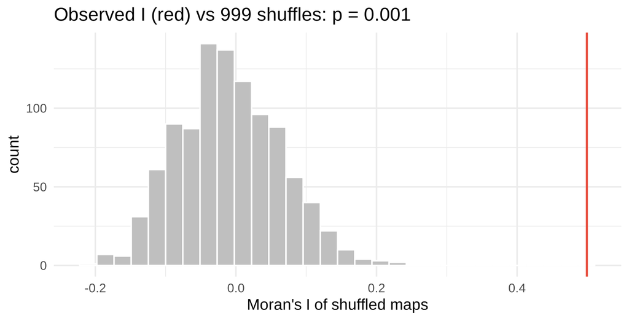

# Topic 2 — The Moran scatterplot

## Value against the average of its neighbours

```r
blocks$z <- as.numeric(scale(blocks$dengue_per_100k)); blocks$lag_z <- lag.listw(lw, blocks$z, zero.policy = TRUE)
ggplot(blocks, aes(z, lag_z)) + geom_hline(yintercept = 0, colour = "grey60") + geom_vline(xintercept = 0, colour = "grey60") +
  geom_point(aes(colour = high_burden), size = 2.4) + geom_smooth(method = "lm", se = FALSE, colour = "black") +
  annotate("text", x = c(2.2, -2.2, 2.2, -2.2), y = c(2.2, -2.2, -2.2, 2.2), label = c("High-High", "Low-Low", "High-Low", "Low-High"), colour = "grey40") +
  labs(x = "Rate (standardised)", y = "Neighbours' average (standardised)", colour = NULL)
```

- The **slope of the line is Moran’s I** (here 0.5)
- **High-High / Low-Low** points make positive autocorrelation
- **High-Low / Low-High** points are **spatial outliers**: LISA (Session 4) finds them

## Value against the average of its neighbours

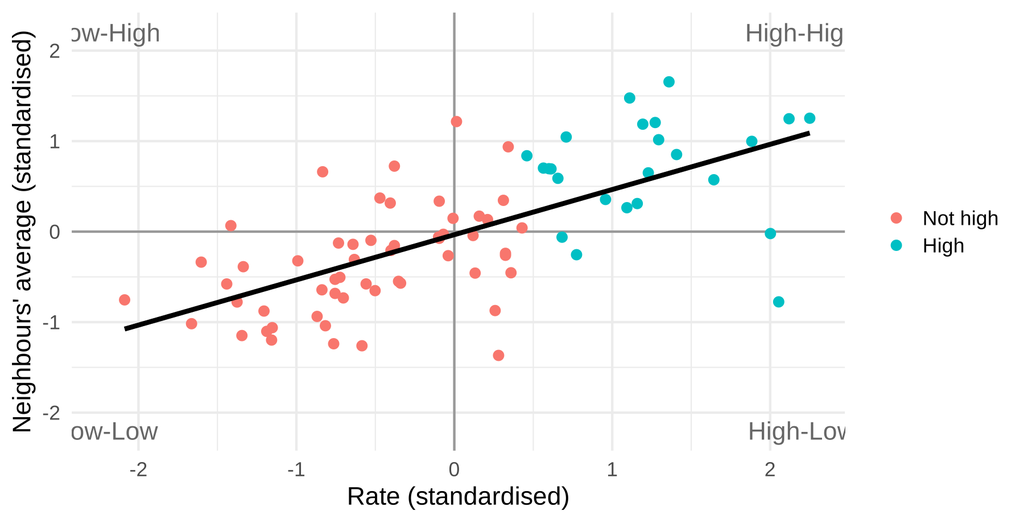

# Topic 3 — Other global tests

## Which global test?

| Test | Question | Variable | Reading |
| --- | --- | --- | --- |
| **Moran’s I** | Are similar values neighbours? | continuous | I > E[I]: clustering |
| **Geary’s C** | Are neighbours’ *differences* small? | continuous | **C < 1** clustering (opposite of I) |
| **General G** | Do **high** or **low** values cluster? | continuous, positive | G > E[G]: highs cluster |
| **Join counts** | Do same-category areas touch? | binary / categorical | more same-category joins than expected |

## Geary’s C, General G, join counts

```r
geary.test(blocks$dengue_per_100k, lw, zero.policy = TRUE)$estimate
```

```
Geary C statistic       Expectation          Variance
      0.466797918       1.000000000       0.004855649
```

```r
lw_b <- nb2listw(nb, style = "B", zero.policy = TRUE)
globalG.test(blocks$dengue_per_100k, lw_b, zero.policy = TRUE)$estimate
```

```
Global G statistic        Expectation           Variance
      7.320125e-02       6.718598e-02       3.916081e-06
```

```r
joincount.test(blocks$high_burden, lw_b, zero.policy = TRUE)[[2]]$estimate
```

```
Same colour statistic           Expectation              Variance
             39.00000              18.54333              10.97242
```

Moran’s I is **positive for both hot-spot and cold-spot clustering**. Only **General G** says whether the **high** values are the ones that cluster. Join counts suit a **yes/no** variable.

## Pitfalls

- Not saying **which weights**; not saying **which variable** (counts and rates differ)
- **Small areas** give noisy rates, which hides or mimics clustering (smooth with empirical Bayes)
- **Edge effects** and the **modifiable areal unit problem**: a different grouping can change I
- A **trend** (north-south gradient) also gives positive I
- A global test **cannot say where**; a non-significant I can hide a local cluster

## How to report

*Dengue incidence was strongly clustered across the 79 blocks (global Moran’s I = 0.50, queen contiguity, row-standardised weights; permutation p = 0.001, 999 simulations).*

Give the statistic, the weights, the number of simulations and the p-value; then say where, with local methods.

## 🔧 Switch to R — Lab 3

**File:** `gis-workshop/labs/lab3_global.R`

- `moran.test()` · `moran.mc()` · the Moran scatterplot data
- `geary.test()` · `globalG.test()` · `joincount.test()`
- a variable with **no** spatial pattern for comparison

**Time:** 35 minutes · answer the Q questions in the comments

## Self-check quiz (1/5)

Global Moran’s I is 0.49 (permutation p = 0.001). What is the best interpretation?

- 49% of the variation in the rate is explained by the location
- Each area’s rate is 0.49 higher than its neighbours’ average rate
- Neighbouring areas are more alike than expected by chance
- About half of all the areas lie in a significant local cluster

## Self-check quiz (2/5)

What is the expected value of Moran’s I when there is no spatial pattern?

- Exactly 1, because every area is its own neighbour
- About 0 (exactly −1/(n−1))
- Exactly 0.5, halfway between the two extremes
- It depends on the data, so there is no expected value

## Self-check quiz (3/5)

With 999 permutations, what is the smallest possible p-value from moran.mc()?

- 0, if the observed I is larger than every one of the shuffled values
- 0.05, which is the usual cut-off used for a significant result
- 0.001, as the observed value is one of 1000 arrangements
- It varies from one data set to another and has no fixed minimum

## Self-check quiz (4/5)

Geary’s C is 0.47. How should this be read?

- Neighbours differ strongly, so negative spatial autocorrelation
- There is no spatial pattern, because C is not equal to zero
- The result is invalid, because C must lie between 0 and 1
- Neighbours are similar, so positive spatial autocorrelation

## Self-check quiz (5/5)

Moran’s I is positive and significant. What does the General G test add?

- Whether high values (hot spots) or low values cluster
- The exact location of each separate cluster on the map
- A correction of the p-value for the multiple testing
- Nothing, because it always gives the same answer as Moran’s I

## Score and take-home

**Your score:**

- **Moran’s I**: are similar values neighbours? Compare with about 0
- Prefer the **permutation p-value**; always give the **weights**
- The **Moran scatterplot** shows slope = I and the four quadrants
- **Geary’s C** (1 = none), **General G** (hot vs cold), **join counts** (binary)

**Next:** Session 4: local clusters and hot spots